# R: Multiple Group Estimation

| multipleGroup {mirt} | R Documentation |
| --- | --- |

## Multiple Group Estimation

### Description

`multipleGroup` performs a full-information maximum-likelihood multiple group analysis for any combination of dichotomous and polytomous data under the item response theory paradigm using either Cai's (2010) Metropolis-Hastings Robbins-Monro (MHRM) algorithm or with an EM algorithm approach. This function may be used for detecting differential item functioning (DIF), thought the `DIF` function may provide a more convenient approach. If the grouping variable is not specified then the `dentype` input can be modified to fit mixture models to estimate any latent group components.

### Usage

```r
multipleGroup(
  data,
  model = 1,
  group,
  itemtype = NULL,
  invariance = "",
  method = "EM",
  dentype = "Gaussian",
  itemdesign = NULL,
  item.formula = NULL,
  ...
)
```

### Arguments

`data`

a `matrix` or `data.frame` that consists of numerically ordered data, organized in the form of integers, with missing data coded as `NA`

`model`

string to be passed to, or a model object returned from, `mirt.model` declaring how the global model is to be estimated (useful to apply constraints here)

`group`

a `character` or `factor` vector indicating group membership. If a `character` vector is supplied this will be automatically transformed into a `factor` variable. As well, the first level of the (factorized) grouping variable will be treated as the "reference" group

`itemtype`

can be same type of input as is documented in `mirt`, however may also be a `ngroups` by `nitems` matrix specifying the type of IRT models for each group, respectively. Rows of this input correspond to the levels of the `group` input. For mixture models the rows correspond to the respective mixture grouping variables to be constructed, and the IRT models should be within these mixtures

`invariance`

a character vector containing the following possible options:

**`'free_mean'` or `'free_means'`**

freely estimate all latent means in all focal groups (reference group constrained to a vector of 0's)

**`'free_var'`, `'free_vars'`, `'free_variance'`, or `'free_variances'`**

freely estimate all latent variances in focal groups (reference group variances all constrained to 1)

**`'slopes'`**

to constrain all the slopes to be equal across all groups

**`'intercepts'`**

to constrain all the intercepts to be equal across all groups, note for nominal models this also includes the category specific slope parameters

Additionally, specifying specific item name bundles (from `colnames(data)`) will constrain all freely estimated parameters in each item to be equal across groups. This is useful for selecting 'anchor' items for vertical and horizontal scaling, and for detecting differential item functioning (DIF) across groups

`method`

a character object that is either `'EM'`, `'QMCEM'`, or `'MHRM'` (default is `'EM'`). See `mirt` for details

`dentype`

type of density form to use for the latent trait parameters. Current options include all of the methods described in `mirt`, as well as

- `'mixture-#'` estimates mixtures of Gaussian distributions, where the `#` placeholder represents the number of potential grouping variables (e.g., `'mixture-3'` will estimate 3 underlying classes). Each class is assigned the group name `MIXTURE_#`, where `#` is the class number. Note that internally the mixture coefficients are stored as log values where the first mixture group coefficient is fixed at 0

`itemdesign`

see `mirt` for details

`item.formula`

see `mirt` for details

`...`

additional arguments to be passed to the estimation engine. See `mirt` for details and examples

### Details

By default the estimation in `multipleGroup` assumes that the models are maximally independent, and therefore could initially be performed by sub-setting the data and running identical models with `mirt` and aggregating the results (e.g., log-likelihood). However, constrains may be automatically imposed across groups by invoking various `invariance` keywords. Users may also supply a list of parameter equality constraints to by `constrain` argument, of define equality constraints using the `mirt.model` syntax (recommended).

### Value

function returns an object of class `MultipleGroupClass` (MultipleGroupClass-class).

### Author(s)

Phil Chalmers rphilip.chalmers@gmail.com

### References

Chalmers, R., P. (2012). mirt: A Multidimensional Item Response Theory Package for the R Environment. *Journal of Statistical Software, 48*(6), 1-29. [doi:10.18637/jss.v048.i06](https://doi.org/10.18637/jss.v048.i06)

Magnus, B. E. and Garnier-Villarreal (2022). A multidimensional zero-inflated graded response model for ordinal symptom data. *Psychological Methods*, 27, 261-279.

Wall, M., M., Park, J., Y., and Moustaki I. (2015). IRT modeling in the presence of zero-inflation with application to psychiatric disorder severity. *Applied Psychological Measurement* 39: 583-597.

### See Also

`mirt`, `DIF`, `extract.group`, `DRF`

### Examples

```r
## No test:

# single factor
set.seed(12345)
a <- matrix(abs(rnorm(15,1,.3)), ncol=1)
d <- matrix(rnorm(15,0,.7),ncol=1)
itemtype <- rep('2PL', nrow(a))
N <- 1000
dataset1 <- simdata(a, d, N, itemtype)
dataset2 <- simdata(a, d, N, itemtype, mu = .1, sigma = matrix(1.5))
dat <- rbind(dataset1, dataset2)
group <- c(rep('D1', N), rep('D2', N))

# marginal information
itemstats(dat)
```

```
## $overall
##     N mean_total.score sd_total.score ave.r  sd.r alpha SEM.alpha
##  2000            7.888          3.555 0.188 0.053 0.777     1.678
##
## $itemstats
##            N  mean    sd total.r total.r_if_rm alpha_if_rm
## Item_1  2000 0.609 0.488   0.525         0.414       0.762
## Item_2  2000 0.392 0.488   0.540         0.431       0.761
## Item_3  2000 0.456 0.498   0.526         0.413       0.762
## Item_4  2000 0.684 0.465   0.461         0.349       0.768
## Item_5  2000 0.538 0.499   0.528         0.415       0.762
## Item_6  2000 0.649 0.477   0.334         0.207       0.779
## Item_7  2000 0.681 0.466   0.524         0.419       0.762
## Item_8  2000 0.432 0.495   0.504         0.389       0.764
## Item_9  2000 0.302 0.459   0.446         0.334       0.769
## Item_10 2000 0.274 0.446   0.388         0.273       0.774
## Item_11 2000 0.734 0.442   0.457         0.351       0.768
## Item_12 2000 0.470 0.499   0.585         0.481       0.756
## Item_13 2000 0.585 0.493   0.561         0.455       0.759
## Item_14 2000 0.592 0.492   0.538         0.428       0.761
## Item_15 2000 0.490 0.500   0.458         0.336       0.769
##
## $proportions
##             0     1
## Item_1  0.392 0.609
## Item_2  0.608 0.392
## Item_3  0.544 0.456
## Item_4  0.316 0.684
## Item_5  0.462 0.538
## Item_6  0.351 0.649
## Item_7  0.318 0.681
## Item_8  0.569 0.432
## Item_9  0.698 0.302
## Item_10 0.726 0.274
## Item_11 0.266 0.734
## Item_12 0.530 0.470
## Item_13 0.416 0.585
## Item_14 0.408 0.592
## Item_15 0.509 0.490
```

```r
# conditional information
itemstats(dat, group=group)
```

```
## $D1
## $D1$overall
##     N mean_total.score sd_total.score ave.r  sd.r alpha SEM.alpha
##  1000             7.82          3.346 0.159 0.047  0.74     1.705
##
## $D1$itemstats
##            N  mean    sd total.r total.r_if_rm alpha_if_rm
## Item_1  1000 0.605 0.489   0.484         0.361       0.725
## Item_2  1000 0.368 0.483   0.507         0.388       0.722
## Item_3  1000 0.461 0.499   0.471         0.343       0.727
## Item_4  1000 0.673 0.469   0.439         0.315       0.729
## Item_5  1000 0.526 0.500   0.500         0.376       0.723
## Item_6  1000 0.654 0.476   0.355         0.222       0.739
## Item_7  1000 0.683 0.466   0.508         0.394       0.722
## Item_8  1000 0.431 0.495   0.462         0.333       0.728
## Item_9  1000 0.287 0.453   0.419         0.298       0.731
## Item_10 1000 0.274 0.446   0.372         0.249       0.735
## Item_11 1000 0.739 0.439   0.401         0.282       0.732
## Item_12 1000 0.456 0.498   0.563         0.448       0.715
## Item_13 1000 0.584 0.493   0.535         0.416       0.719
## Item_14 1000 0.592 0.492   0.483         0.358       0.725
## Item_15 1000 0.487 0.500   0.451         0.321       0.729
##
## $D1$proportions
##             0     1
## Item_1  0.395 0.605
## Item_2  0.632 0.368
## Item_3  0.539 0.461
## Item_4  0.327 0.673
## Item_5  0.474 0.526
## Item_6  0.346 0.654
## Item_7  0.317 0.683
## Item_8  0.569 0.431
## Item_9  0.713 0.287
## Item_10 0.726 0.274
## Item_11 0.261 0.739
## Item_12 0.544 0.456
## Item_13 0.416 0.584
## Item_14 0.408 0.592
## Item_15 0.513 0.487
```

[output cut: 27 more lines]

```
## Item_1  0.388 0.612
## Item_2  0.583 0.417
## Item_3  0.550 0.450
## Item_4  0.305 0.695
## Item_5  0.449 0.551
## Item_6  0.356 0.644
## Item_7  0.320 0.680
## Item_8  0.568 0.432
## Item_9  0.683 0.317
## Item_10 0.725 0.275
## Item_11 0.271 0.729
## Item_12 0.517 0.483
## Item_13 0.415 0.585
## Item_14 0.409 0.591
## Item_15 0.506 0.494
```

```r
mod_configural <- multipleGroup(dat, 1, group = group) #completely separate analyses
# limited information fit statistics
M2(mod_configural)
```

```
##             M2  df         p RMSEA RMSEA_5 RMSEA_95   SRMSR.D1   SRMSR.D2
## stats 142.9866 180 0.9806548     0       0        0 0.02414868 0.01901262
##            TLI CFI
## stats 1.005381   1
```

```r
mod_metric <- multipleGroup(dat, 1, group = group, invariance=c('slopes')) #equal slopes
# equal intercepts, free variance and means
mod_scalar2 <- multipleGroup(dat, 1, group = group,
                             invariance=c('slopes', 'intercepts', 'free_var','free_means'))
mod_scalar1 <- multipleGroup(dat, 1, group = group,  #fixed means
                             invariance=c('slopes', 'intercepts', 'free_var'))
mod_fullconstrain <- multipleGroup(dat, 1, group = group,
                             invariance=c('slopes', 'intercepts'))
extract.mirt(mod_fullconstrain, 'time') #time of estimation components
```

```
## TOTAL:   Data  Estep  Mstep     SE   Post
##  0.428  0.089  0.096  0.225  0.000  0.001
```

```r
# optionally use Newton-Raphson for (generally) faster convergence in the
#  M-step's, though occasionally less stable
mod_fullconstrain <- multipleGroup(dat, 1, group = group, optimizer = 'NR',
                             invariance=c('slopes', 'intercepts'))
extract.mirt(mod_fullconstrain, 'time') #time of estimation components
```

```
## TOTAL:   Data  Estep  Mstep     SE   Post
##  0.271  0.077  0.107  0.070  0.000  0.001
```

```r
summary(mod_scalar2)
```

```
##
## ----------
## GROUP: D1
##            F1     h2
## Item_1  0.544 0.2962
## Item_2  0.577 0.3324
## Item_3  0.529 0.2799
## Item_4  0.460 0.2118
## Item_5  0.536 0.2877
## Item_6  0.253 0.0639
## Item_7  0.570 0.3247
## Item_8  0.498 0.2479
## Item_9  0.459 0.2104
## Item_10 0.373 0.1393
## Item_11 0.487 0.2368
## Item_12 0.632 0.3998
## Item_13 0.596 0.3547
## Item_14 0.561 0.3147
## Item_15 0.414 0.1715
##
## SS loadings:  3.872
## Proportion Var:  0.258
##
## Factor correlations:
##
##    F1
## F1  1
##
## ----------
## GROUP: D2
##            F1     h2
## Item_1  0.634 0.4017
## Item_2  0.665 0.4426
## Item_3  0.619 0.3827
## Item_4  0.548 0.3000
## Item_5  0.626 0.3919
## Item_6  0.313 0.0981
## Item_7  0.659 0.4341
## Item_8  0.587 0.3446
## Item_9  0.546 0.2983
## Item_10 0.453 0.2052
## Item_11 0.575 0.3311
## Item_12 0.718 0.5152
## Item_13 0.683 0.4671
## Item_14 0.650 0.4228
## Item_15 0.498 0.2483
##
## SS loadings:  5.284
## Proportion Var:  0.352
##
## Factor correlations:
##
##    F1
## F1  1
```

```r
coef(mod_scalar2, simplify=TRUE)
```

```
## $D1
## $items
##            a1      d g u
## Item_1  1.104  0.538 0 1
## Item_2  1.201 -0.630 0 1
## Item_3  1.061 -0.265 0 1
## Item_4  0.882  0.900 0 1
## Item_5  1.082  0.164 0 1
## Item_6  0.445  0.636 0 1
## Item_7  1.180  0.976 0 1
## Item_8  0.977 -0.377 0 1
## Item_9  0.879 -1.035 0 1
## Item_10 0.685 -1.118 0 1
## Item_11 0.948  1.213 0 1
## Item_12 1.389 -0.224 0 1
## Item_13 1.262  0.429 0 1
## Item_14 1.153  0.453 0 1
## Item_15 0.774 -0.070 0 1
##
## $means
## F1
##  0
##
## $cov
##    F1
## F1  1
##
##
## $D2
## $items
##            a1      d g u
## Item_1  1.104  0.538 0 1
## Item_2  1.201 -0.630 0 1
## Item_3  1.061 -0.265 0 1
## Item_4  0.882  0.900 0 1
## Item_5  1.082  0.164 0 1
## Item_6  0.445  0.636 0 1
## Item_7  1.180  0.976 0 1
## Item_8  0.977 -0.377 0 1
## Item_9  0.879 -1.035 0 1
## Item_10 0.685 -1.118 0 1
## Item_11 0.948  1.213 0 1
## Item_12 1.389 -0.224 0 1
## Item_13 1.262  0.429 0 1
## Item_14 1.153  0.453 0 1
## Item_15 0.774 -0.070 0 1
##
## $means
##    F1
## 0.066
##
## $cov
##       F1
## F1 1.595
```

```r
residuals(mod_scalar2)
```

```
## $D1
##         Item_1 Item_2 Item_3 Item_4 Item_5 Item_6 Item_7 Item_8 Item_9 Item_10
## Item_1      NA -0.036 -0.056  0.036 -0.014  0.014  0.017 -0.020 -0.008  -0.066
## Item_2   1.305     NA -0.052 -0.032 -0.031  0.033 -0.028  0.034  0.038   0.042
## Item_3   3.144  2.659     NA -0.047  0.057  0.071 -0.037 -0.050  0.033  -0.047
## Item_4   1.279  1.041  2.173     NA  0.029  0.035  0.032 -0.039 -0.038   0.032
## Item_5   0.198  0.932  3.291  0.862     NA  0.029  0.048 -0.028  0.027  -0.027
## Item_6   0.204  1.059  5.032  1.197  0.830     NA  0.020  0.034  0.023   0.041
## Item_7   0.277  0.804  1.362  1.018  2.337  0.392     NA -0.023 -0.040   0.038
## Item_8   0.402  1.143  2.483  1.545  0.774  1.125  0.518     NA -0.027   0.025
## Item_9   0.067  1.478  1.062  1.471  0.717  0.523  1.631  0.726     NA   0.052
## Item_10  4.303  1.756  2.228  1.054  0.744  1.649  1.453  0.610  2.692      NA
## Item_11  0.361  3.951  0.988  1.197  0.910  1.320  0.139  2.072  2.295   1.368
## Item_12  1.718  0.586  1.038  0.725  0.218  0.454  1.323  0.473  0.322   0.604
## Item_13  0.194  3.315  1.368  1.158  0.797  0.517  0.045  0.395  0.200   2.690
## Item_14  0.074  0.804  3.798  2.946  0.648  0.228  0.223  0.463  0.693   0.378
## Item_15  0.164  1.266  0.869  6.383  4.884  1.982  0.583  1.563  1.130   2.406
##         Item_11 Item_12 Item_13 Item_14 Item_15
## Item_1   -0.019   0.041  -0.014  -0.009   0.013
## Item_2   -0.063   0.024   0.058   0.028   0.036
## Item_3   -0.031   0.032  -0.037  -0.062   0.029
## Item_4    0.035   0.027  -0.034  -0.054   0.080
## Item_5   -0.030   0.015   0.028  -0.025  -0.070
## Item_6    0.036   0.021   0.023  -0.015   0.045
## Item_7    0.012   0.036  -0.007   0.015   0.024
## Item_8   -0.046   0.022   0.020  -0.022   0.040
## Item_9   -0.048  -0.018  -0.014   0.026   0.034
## Item_10   0.037   0.025   0.052  -0.019  -0.049
## Item_11      NA   0.010  -0.024  -0.053   0.021
## Item_12   0.094      NA  -0.016  -0.016   0.012
## Item_13   0.555   0.254      NA  -0.013   0.022
## Item_14   2.862   0.255   0.159      NA   0.009
## Item_15   0.424   0.148   0.486   0.073      NA
##
## $D2
##         Item_1 Item_2 Item_3 Item_4 Item_5 Item_6 Item_7 Item_8 Item_9 Item_10
## Item_1      NA -0.029  0.031 -0.026  0.021 -0.042 -0.006  0.039  0.010  -0.029
## Item_2   0.861     NA  0.047 -0.060  0.049 -0.061 -0.036 -0.036  0.043   0.035
## Item_3   0.973  2.251     NA  0.064  0.039 -0.029  0.033  0.045  0.042   0.031
## Item_4   0.673  3.547  4.082     NA  0.034  0.045  0.029  0.033 -0.031  -0.053
```

[output cut: 12 more lines]

```
## Item_1    0.029   0.009   0.024   0.020   0.018
## Item_2    0.029  -0.039   0.038   0.039  -0.036
## Item_3    0.028   0.033   0.029   0.030   0.035
## Item_4    0.043  -0.025  -0.033   0.036  -0.031
## Item_5    0.018  -0.018  -0.025   0.023  -0.049
## Item_6    0.015  -0.021   0.020  -0.028  -0.036
## Item_7   -0.008  -0.010  -0.020   0.023  -0.025
## Item_8    0.053  -0.024  -0.025   0.056   0.017
## Item_9   -0.017  -0.020  -0.037   0.012  -0.017
## Item_10   0.020   0.023  -0.022   0.019   0.018
## Item_11      NA   0.032   0.017   0.018   0.024
## Item_12   1.010      NA   0.014  -0.022  -0.011
## Item_13   0.280   0.185      NA   0.022  -0.012
## Item_14   0.333   0.480   0.479      NA  -0.007
## Item_15   0.580   0.131   0.145   0.048      NA
```

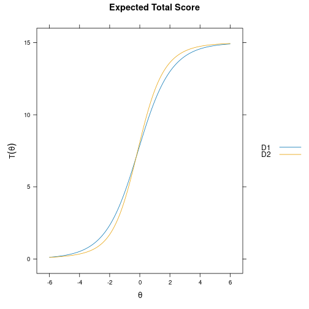

```r
plot(mod_configural)
```

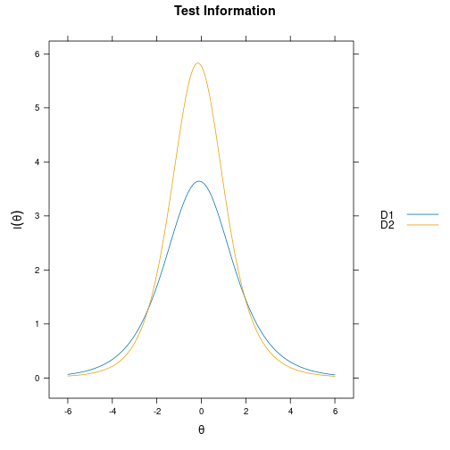

```r
plot(mod_configural, type = 'info')
```

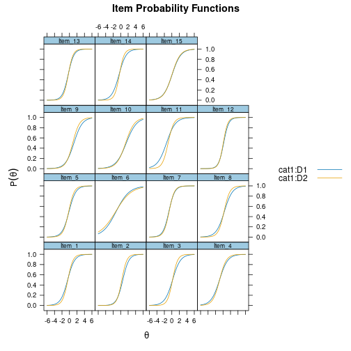

```r
plot(mod_configural, type = 'trace')
```

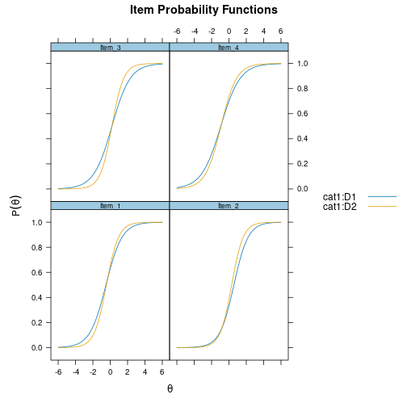

```r
plot(mod_configural, type = 'trace', which.items = 1:4)
```

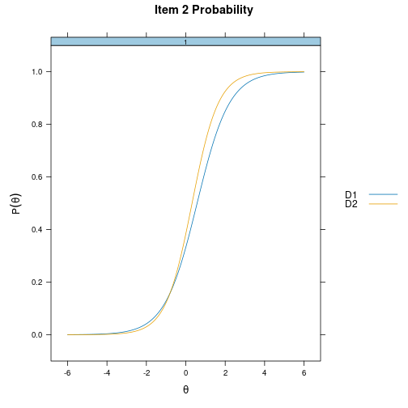

```r
itemplot(mod_configural, 2)
```

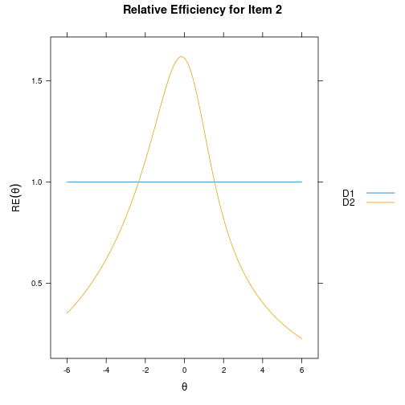

```r
itemplot(mod_configural, 2, type = 'RE')
```

```r
anova(mod_metric, mod_configural) #equal slopes only
```

```
##                     AIC    SABIC       HQ      BIC    logLik    X2 df p
## mod_metric     35937.61 36046.68 36030.15 36189.65 -17923.80
## mod_configural 35927.53 36072.96 36050.92 36263.58 -17903.76 40.08 15 0
```

```r
anova(mod_scalar2, mod_metric) #equal intercepts, free variance and mean
```

```
##                  AIC    SABIC       HQ      BIC    logLik      X2 df   p
## mod_scalar2 35894.66 35972.22 35960.47 36073.89 -17915.33
## mod_metric  35937.61 36046.68 36030.15 36189.65 -17923.80 -16.947 13 NaN
```

```r
anova(mod_scalar1, mod_scalar2) #fix mean
```

```
##                  AIC    SABIC       HQ      BIC    logLik    X2 df     p
## mod_scalar1 35893.96 35969.10 35957.71 36067.58 -17915.98
## mod_scalar2 35894.66 35972.22 35960.47 36073.89 -17915.33 1.296  1 0.255
```

```r
anova(mod_fullconstrain, mod_scalar1) #fix variance
```

```
##                        AIC    SABIC       HQ      BIC    logLik     X2 df p
## mod_fullconstrain 35917.51 35990.22 35979.20 36085.53 -17928.75
## mod_scalar1       35893.96 35969.10 35957.71 36067.58 -17915.98 25.552  1 0
```

```r
# compared all at once (in order of most constrained to least)
anova(mod_fullconstrain, mod_scalar2, mod_configural)
```

```
##                        AIC    SABIC       HQ      BIC    logLik     X2 df     p
## mod_fullconstrain 35917.51 35990.22 35979.20 36085.53 -17928.75
## mod_scalar2       35894.66 35972.22 35960.47 36073.89 -17915.33 26.848  2     0
## mod_configural    35927.53 36072.96 36050.92 36263.58 -17903.76 23.133 28 0.726
```

```r
# test whether first 6 slopes should be equal across groups
values <- multipleGroup(dat, 1, group = group, pars = 'values')
values
```

```
##     group    item     class   name parnum  value lbound ubound   est const
## 1      D1  Item_1      dich     a1      1  0.851   -Inf    Inf  TRUE  none
## 2      D1  Item_1      dich      d      2  0.541   -Inf    Inf  TRUE  none
## 3      D1  Item_1      dich      g      3  0.000      0      1 FALSE  none
## 4      D1  Item_1      dich      u      4  1.000      0      1 FALSE  none
## 5      D1  Item_2      dich     a1      5  0.851   -Inf    Inf  TRUE  none
## 6      D1  Item_2      dich      d      6 -0.536   -Inf    Inf  TRUE  none
## 7      D1  Item_2      dich      g      7  0.000      0      1 FALSE  none
## 8      D1  Item_2      dich      u      8  1.000      0      1 FALSE  none
## 9      D1  Item_3      dich     a1      9  0.851   -Inf    Inf  TRUE  none
## 10     D1  Item_3      dich      d     10 -0.220   -Inf    Inf  TRUE  none
## 11     D1  Item_3      dich      g     11  0.000      0      1 FALSE  none
## 12     D1  Item_3      dich      u     12  1.000      0      1 FALSE  none
## 13     D1  Item_4      dich     a1     13  0.851   -Inf    Inf  TRUE  none
## 14     D1  Item_4      dich      d     14  0.941   -Inf    Inf  TRUE  none
```

[output cut: 235 more lines]

```r
constrain <- list(c(1, 63), c(5,67), c(9,71), c(13,75), c(17,79), c(21,83))
equalslopes <- multipleGroup(dat, 1, group = group, constrain = constrain)
anova(equalslopes, mod_configural)
```

```
##                     AIC    SABIC       HQ      BIC    logLik     X2 df     p
## equalslopes    35935.51 36066.40 36046.56 36237.96 -17913.76
## mod_configural 35927.53 36072.96 36050.92 36263.58 -17903.76 19.983  6 0.003
```

```r
# same as above, but using mirt.model syntax
newmodel <- '
    F = 1-15
    CONSTRAINB = (1-6, a1)'
equalslopes <- multipleGroup(dat, newmodel, group = group)
coef(equalslopes, simplify=TRUE)
```

```
## $D1
## $items
##            a1      d g u
## Item_1  1.246  0.546 0 1
## Item_2  1.356 -0.720 0 1
## Item_3  1.199 -0.201 0 1
## Item_4  1.006  0.861 0 1
## Item_5  1.224  0.131 0 1
## Item_6  0.515  0.673 0 1
## Item_7  1.305  0.999 0 1
## Item_8  0.943 -0.328 0 1
## Item_9  0.916 -1.058 0 1
## Item_10 0.731 -1.079 0 1
## Item_11 0.851  1.186 0 1
## Item_12 1.515 -0.251 0 1
## Item_13 1.322  0.444 0 1
## Item_14 1.058  0.451 0 1
## Item_15 0.885 -0.061 0 1
##
## $means
## F
## 0
##
## $cov
##   F
## F 1
##
##
## $D2
## $items
##            a1      d g u
## Item_1  1.246  0.599 0 1
## Item_2  1.356 -0.462 0 1
## Item_3  1.199 -0.264 0 1
## Item_4  1.006  1.001 0 1
## Item_5  1.224  0.266 0 1
## Item_6  0.515  0.631 0 1
## Item_7  1.374  1.031 0 1
## Item_8  1.268 -0.367 0 1
## Item_9  1.061 -0.952 0 1
## Item_10 0.826 -1.115 0 1
## Item_11 1.282  1.308 0 1
## Item_12 1.625 -0.107 0 1
## Item_13 1.523  0.493 0 1
## Item_14 1.545  0.532 0 1
## Item_15 0.885 -0.030 0 1
##
## $means
## F
## 0
##
## $cov
##   F
## F 1
```

```r
############
# vertical scaling (i.e., equating when groups answer items others do not)
dat2 <- dat
dat2[group == 'D1', 1:2] <- dat2[group != 'D1', 14:15] <- NA
head(dat2)
```

```
##      Item_1 Item_2 Item_3 Item_4 Item_5 Item_6 Item_7 Item_8 Item_9 Item_10
## [1,]     NA     NA      1      1      1      0      1      1      0       0
## [2,]     NA     NA      1      1      1      1      1      0      1       0
## [3,]     NA     NA      0      1      1      1      1      1      0       0
## [4,]     NA     NA      1      1      1      1      1      1      0       0
## [5,]     NA     NA      1      0      1      1      1      1      1       0
## [6,]     NA     NA      1      1      1      1      1      0      0       0
##      Item_11 Item_12 Item_13 Item_14 Item_15
## [1,]       1       1       0       1       1
## [2,]       0       1       1       1       1
## [3,]       1       0       1       1       1
## [4,]       1       1       1       1       1
## [5,]       1       1       1       1       1
## [6,]       1       1       1       1       0
```

```r
tail(dat2)
```

```
##         Item_1 Item_2 Item_3 Item_4 Item_5 Item_6 Item_7 Item_8 Item_9 Item_10
## [1995,]      1      1      0      0      0      1      1      1      0       0
## [1996,]      1      0      1      1      1      0      1      1      1       1
## [1997,]      0      1      0      0      0      1      0      1      0       0
## [1998,]      0      1      0      0      1      0      0      0      0       0
## [1999,]      1      1      0      1      1      1      1      1      0       0
## [2000,]      0      0      0      0      0      0      1      0      0       0
##         Item_11 Item_12 Item_13 Item_14 Item_15
## [1995,]       1       0       1      NA      NA
## [1996,]       1       1       0      NA      NA
## [1997,]       1       0       1      NA      NA
## [1998,]       0       1       0      NA      NA
## [1999,]       1       1       1      NA      NA
## [2000,]       0       0       0      NA      NA
```

```r
# items with missing responses need to be constrained across groups for identification
nms <- colnames(dat2)
mod <- multipleGroup(dat2, 1, group, invariance = nms[c(1:2, 14:15)])

# this will throw an error without proper constraints (SEs cannot be computed either)
# mod <- multipleGroup(dat2, 1, group)

# model still does not have anchors, therefore need to add a few (here use items 3-5)
mod_anchor <- multipleGroup(dat2, 1, group,
                            invariance = c(nms[c(1:5, 14:15)], 'free_means', 'free_var'))
coef(mod_anchor, simplify=TRUE)
```

[output not shown]

```r
# check if identified by computing information matrix
mod_anchor <- multipleGroup(dat2, 1, group, pars = mod2values(mod_anchor), TOL=NaN, SE=TRUE,
                            invariance = c(nms[c(1:5, 14:15)], 'free_means', 'free_var'))
mod_anchor
```

[output not shown]

```r
coef(mod_anchor)
```

```
## $D1
## $Item_1
##            a1     d  g  u
## par     1.108 0.542  0  1
## CI_2.5  0.842 0.330 NA NA
## CI_97.5 1.375 0.753 NA NA
##
## $Item_2
##            a1      d  g  u
## par     1.160 -0.564  0  1
## CI_2.5  0.883 -0.785 NA NA
## CI_97.5 1.436 -0.342 NA NA
##
## $Item_3
##            a1      d  g  u
## par     1.073 -0.272  0  1
## CI_2.5  0.896 -0.408 NA NA
## CI_97.5 1.250 -0.137 NA NA
##
## $Item_4
##            a1     d  g  u
## par     0.871 0.895  0  1
## CI_2.5  0.710 0.765 NA NA
## CI_97.5 1.031 1.026 NA NA
##
## $Item_5
##            a1     d  g  u
## par     1.089 0.160  0  1
## CI_2.5  0.906 0.024 NA NA
## CI_97.5 1.272 0.295 NA NA
##
## $Item_6
##            a1     d  g  u
## par     0.582 0.685  0  1
## CI_2.5  0.405 0.543 NA NA
## CI_97.5 0.760 0.828 NA NA
##
## $Item_7
##            a1     d  g  u
## par     1.292 1.009  0  1
```

[output cut: 139 more lines]

```
## par     1.000 0.449  0  1
## CI_2.5  0.785 0.294 NA NA
## CI_97.5 1.215 0.603 NA NA
##
## $Item_15
##            a1      d  g  u
## par     0.852 -0.061  0  1
## CI_2.5  0.655 -0.205 NA NA
## CI_97.5 1.049  0.083 NA NA
##
## $GroupPars
##         MEAN_1 COV_11
## par      0.008  1.658
## CI_2.5  -0.148  1.093
## CI_97.5  0.164  2.222
```

```r
coef(mod_anchor, printSE=TRUE)
```

```
## $D1
## $Item_1
##        a1     d logit(g) logit(u)
## par 1.108 0.542     -999      999
## SE  0.136 0.108       NA       NA
##
## $Item_2
##        a1      d logit(g) logit(u)
## par 1.160 -0.564     -999      999
## SE  0.141  0.113       NA       NA
##
## $Item_3
##        a1      d logit(g) logit(u)
## par 1.073 -0.272     -999      999
## SE  0.090  0.069       NA       NA
##
## $Item_4
##        a1     d logit(g) logit(u)
## par 0.871 0.895     -999      999
## SE  0.082 0.066       NA       NA
##
## $Item_5
##        a1     d logit(g) logit(u)
## par 1.089 0.160     -999      999
## SE  0.093 0.069       NA       NA
##
## $Item_6
##        a1     d logit(g) logit(u)
## par 0.582 0.685     -999      999
## SE  0.091 0.073       NA       NA
##
## $Item_7
##        a1     d logit(g) logit(u)
## par 1.292 1.009     -999      999
## SE  0.135 0.097       NA       NA
##
## $Item_8
##        a1      d logit(g) logit(u)
## par 0.906 -0.328     -999      999
## SE  0.104  0.076       NA       NA
```

[output cut: 107 more lines]

```
##
## $Item_14
##       a1     d logit(g) logit(u)
## par 1.00 0.449     -999      999
## SE  0.11 0.079       NA       NA
##
## $Item_15
##        a1      d logit(g) logit(u)
## par 0.852 -0.061     -999      999
## SE  0.100  0.073       NA       NA
##
## $GroupPars
##     MEAN_1 COV_11
## par  0.008  1.658
## SE   0.080  0.288
```

```r
#############
# DIF test for each item (using all other items as anchors)
itemnames <- colnames(dat)
refmodel <- multipleGroup(dat, 1, group = group, SE=TRUE,
                          invariance=c('free_means', 'free_var', itemnames))

# loop over items (in practice, run in parallel to increase speed). May be better to use ?DIF
estmodels <- vector('list', ncol(dat))
for(i in 1:ncol(dat))
    estmodels[[i]] <- multipleGroup(dat, 1, group = group, verbose = FALSE,
                             invariance=c('free_means', 'free_var', itemnames[-i]))
anova(refmodel, estmodels[[1]])
```

```
##                     AIC    SABIC       HQ      BIC    logLik    X2 df     p
## refmodel       35894.66 35972.22 35960.47 36073.89 -17915.33
## estmodels[[1]] 35898.45 35980.86 35968.37 36088.88 -17915.22 0.213  2 0.899
```

```r
(anovas <- lapply(estmodels, function(x, refmodel) anova(refmodel, x),
   refmodel=refmodel))
```

```
## [[1]]
##               AIC    SABIC       HQ      BIC    logLik    X2 df     p
## refmodel 35894.66 35972.22 35960.47 36073.89 -17915.33
## x        35898.45 35980.86 35968.37 36088.88 -17915.22 0.213  2 0.899
##
## [[2]]
##               AIC    SABIC       HQ      BIC    logLik    X2 df     p
## refmodel 35894.66 35972.22 35960.47 36073.89 -17915.33
## x        35896.81 35979.22 35966.73 36087.24 -17914.41 1.847  2 0.397
##
## [[3]]
##               AIC    SABIC       HQ      BIC    logLik    X2 df     p
## refmodel 35894.66 35972.22 35960.47 36073.89 -17915.33
## x        35893.66 35976.07 35963.58 36084.09 -17912.83 5.001  2 0.082
##
## [[4]]
##               AIC    SABIC       HQ      BIC    logLik    X2 df     p
## refmodel 35894.66 35972.22 35960.47 36073.89 -17915.33
## x        35897.07 35979.48 35967.00 36087.50 -17914.54 1.586  2 0.453
##
## [[5]]
##               AIC    SABIC       HQ      BIC    logLik    X2 df     p
## refmodel 35894.66 35972.22 35960.47 36073.89 -17915.33
## x        35897.97 35980.38 35967.89 36088.40 -17914.99 0.688  2 0.709
##
## [[6]]
##               AIC    SABIC       HQ      BIC    logLik    X2 df    p
## refmodel 35894.66 35972.22 35960.47 36073.89 -17915.33
## x        35894.87 35977.28 35964.79 36085.30 -17913.43 3.793  2 0.15
##
## [[7]]
##               AIC    SABIC       HQ      BIC    logLik    X2 df     p
## refmodel 35894.66 35972.22 35960.47 36073.89 -17915.33
## x        35897.53 35979.94 35967.45 36087.96 -17914.76 1.131  2 0.568
##
## [[8]]
##               AIC    SABIC       HQ      BIC    logLik    X2 df     p
## refmodel 35894.66 35972.22 35960.47 36073.89 -17915.33
## x        35897.20 35979.61 35967.12 36087.63 -17914.60 1.462  2 0.481
##
```

[output cut: 19 more lines]

```
##
## [[13]]
##               AIC    SABIC       HQ      BIC    logLik    X2 df     p
## refmodel 35894.66 35972.22 35960.47 36073.89 -17915.33
## x        35898.47 35980.88 35968.39 36088.90 -17915.23 0.192  2 0.908
##
## [[14]]
##               AIC    SABIC       HQ      BIC    logLik    X2 df     p
## refmodel 35894.66 35972.22 35960.47 36073.89 -17915.33
## x        35896.15 35978.57 35966.08 36086.58 -17914.08 2.505  2 0.286
##
## [[15]]
##               AIC    SABIC       HQ      BIC    logLik    X2 df     p
## refmodel 35894.66 35972.22 35960.47 36073.89 -17915.33
## x        35896.96 35979.37 35966.88 36087.39 -17914.48 1.699  2 0.428
```

```r
# family-wise error control
p <- do.call(rbind, lapply(anovas, function(x) x[2, 'p']))
p.adjust(p, method = 'BH')
```

```
##  [1] 0.9084068 0.8299977 0.8299977 0.8299977 0.8862361 0.8299977 0.8299977
##  [8] 0.8299977 0.9084068 0.8299977 0.8299977 0.8299977 0.9084068 0.8299977
## [15] 0.8299977
```

```r
# same as above, except only test if slopes vary (1 df)
# constrain all intercepts
estmodels <- vector('list', ncol(dat))
for(i in 1:ncol(dat))
    estmodels[[i]] <- multipleGroup(dat, 1, group = group, verbose = FALSE,
                             invariance=c('free_means', 'free_var', 'intercepts',
                             itemnames[-i]))

(anovas <- lapply(estmodels, function(x, refmodel) anova(refmodel, x),
   refmodel=refmodel))
```

```
## [[1]]
##               AIC    SABIC       HQ      BIC    logLik    X2 df     p
## refmodel 35894.66 35972.22 35960.47 36073.89 -17915.33
## x        35896.52 35976.50 35964.38 36081.35 -17915.26 0.143  1 0.705
##
## [[2]]
##               AIC    SABIC       HQ      BIC    logLik    X2 df     p
## refmodel 35894.66 35972.22 35960.47 36073.89 -17915.33
## x        35896.60 35976.58 35964.46 36081.43 -17915.30 0.061  1 0.804
##
## [[3]]
##               AIC    SABIC       HQ      BIC    logLik    X2 df     p
## refmodel 35894.66 35972.22 35960.47 36073.89 -17915.33
## x        35894.66 35974.65 35962.53 36079.49 -17914.33 1.997  1 0.158
##
## [[4]]
##               AIC    SABIC       HQ      BIC    logLik    X2 df     p
## refmodel 35894.66 35972.22 35960.47 36073.89 -17915.33
## x        35896.39 35976.38 35964.26 36081.22 -17915.20 0.268  1 0.605
##
## [[5]]
##               AIC    SABIC       HQ      BIC    logLik    X2 df     p
## refmodel 35894.66 35972.22 35960.47 36073.89 -17915.33
## x        35896.56 35976.54 35964.42 36081.39 -17915.28 0.103  1 0.748
##
## [[6]]
##               AIC    SABIC       HQ      BIC    logLik    X2 df     p
## refmodel 35894.66 35972.22 35960.47 36073.89 -17915.33
## x        35893.62 35973.60 35961.48 36078.45 -17913.81 3.042  1 0.081
##
## [[7]]
##               AIC    SABIC       HQ      BIC    logLik    X2 df     p
## refmodel 35894.66 35972.22 35960.47 36073.89 -17915.33
## x        35895.67 35975.66 35963.54 36080.50 -17914.84 0.985  1 0.321
##
## [[8]]
##               AIC    SABIC       HQ      BIC    logLik   X2 df     p
## refmodel 35894.66 35972.22 35960.47 36073.89 -17915.33
## x        35896.27 35976.26 35964.13 36081.10 -17915.13 0.39  1 0.532
##
```

[output cut: 19 more lines]

```
##
## [[13]]
##               AIC    SABIC       HQ      BIC    logLik   X2 df     p
## refmodel 35894.66 35972.22 35960.47 36073.89 -17915.33
## x        35896.58 35976.57 35964.44 36081.41 -17915.29 0.08  1 0.778
##
## [[14]]
##               AIC    SABIC       HQ      BIC    logLik  X2 df     p
## refmodel 35894.66 35972.22 35960.47 36073.89 -17915.33
## x        35894.16 35974.15 35962.02 36078.99 -17914.08 2.5  1 0.114
##
## [[15]]
##               AIC    SABIC       HQ      BIC    logLik    X2 df     p
## refmodel 35894.66 35972.22 35960.47 36073.89 -17915.33
## x        35894.99 35974.97 35962.85 36079.82 -17914.49 1.672  1 0.196
```

```r
# quickly test with Wald test using DIF()
mod_configural2 <- multipleGroup(dat, 1, group = group, SE=TRUE)
DIF(mod_configural2, which.par = c('a1', 'd'), Wald=TRUE, p.adjust = 'fdr')
```

```
## NOTE: No hyper-parameters were estimated in the DIF model.
##       For effective DIF testing, freeing the focal group hyper-parameters is recommended.
```

```
##         groups      W df     p adj_p
## Item_1   D1,D2  4.636  2 0.098 0.246
## Item_2   D1,D2  7.265  2 0.026 0.099
## Item_3   D1,D2 10.375  2 0.006 0.055
## Item_4   D1,D2  3.210  2 0.201 0.335
## Item_5   D1,D2  3.618  2 0.164 0.307
## Item_6   D1,D2  0.820  2 0.664 0.804
## Item_7   D1,D2  0.575  2  0.75 0.804
## Item_8   D1,D2  5.782  2 0.056 0.167
## Item_9   D1,D2  3.802  2 0.149 0.307
## Item_10  D1,D2  0.722  2 0.697 0.804
## Item_11  D1,D2  8.922  2 0.012 0.058
## Item_12  D1,D2  2.340  2  0.31 0.463
## Item_13  D1,D2  2.162  2 0.339 0.463
## Item_14  D1,D2  9.848  2 0.007 0.055
## Item_15  D1,D2  0.204  2 0.903 0.903
```

```r
#############
# Three group model where the latent variable parameters are constrained to
# be equal in the focal groups

set.seed(12345)
a <- matrix(abs(rnorm(15,1,.3)), ncol=1)
d <- matrix(rnorm(15,0,.7),ncol=1)
itemtype <- rep('2PL', nrow(a))
N <- 1000
dataset1 <- simdata(a, d, N, itemtype)
dataset2 <- simdata(a, d, N, itemtype, mu = .1, sigma = matrix(1.5))
dataset3 <- simdata(a, d, N, itemtype, mu = .1, sigma = matrix(1.5))
dat <- rbind(dataset1, dataset2, dataset3)
group <- rep(c('D1', 'D2', 'D3'), each=N)

# marginal information
itemstats(dat)
```

```
## $overall
##     N mean_total.score sd_total.score ave.r  sd.r alpha SEM.alpha
##  3000             7.89          3.567  0.19 0.054 0.779     1.676
##
## $itemstats
##            N  mean    sd total.r total.r_if_rm alpha_if_rm
## Item_1  3000 0.605 0.489   0.525         0.415       0.764
## Item_2  3000 0.403 0.491   0.563         0.458       0.761
## Item_3  3000 0.457 0.498   0.504         0.388       0.767
## Item_4  3000 0.676 0.468   0.458         0.345       0.770
## Item_5  3000 0.545 0.498   0.539         0.429       0.763
## Item_6  3000 0.645 0.478   0.334         0.207       0.782
## Item_7  3000 0.688 0.464   0.529         0.426       0.764
## Item_8  3000 0.427 0.495   0.498         0.382       0.767
## Item_9  3000 0.292 0.455   0.454         0.344       0.770
## Item_10 3000 0.284 0.451   0.393         0.279       0.775
## Item_11 3000 0.738 0.440   0.451         0.345       0.770
## Item_12 3000 0.460 0.499   0.598         0.496       0.757
## Item_13 3000 0.591 0.492   0.556         0.449       0.761
## Item_14 3000 0.591 0.492   0.548         0.441       0.762
## Item_15 3000 0.488 0.500   0.452         0.330       0.772
##
## $proportions
##             0     1
## Item_1  0.395 0.605
## Item_2  0.597 0.403
## Item_3  0.543 0.457
## Item_4  0.324 0.676
## Item_5  0.455 0.545
## Item_6  0.355 0.645
## Item_7  0.312 0.688
## Item_8  0.573 0.427
## Item_9  0.708 0.292
## Item_10 0.716 0.284
## Item_11 0.262 0.738
## Item_12 0.540 0.460
## Item_13 0.409 0.591
## Item_14 0.409 0.591
## Item_15 0.512 0.488
```

```r
# conditional information
itemstats(dat, group=group)
```

```
## $D1
## $D1$overall
##     N mean_total.score sd_total.score ave.r  sd.r alpha SEM.alpha
##  1000             7.82          3.346 0.159 0.047  0.74     1.705
##
## $D1$itemstats
##            N  mean    sd total.r total.r_if_rm alpha_if_rm
## Item_1  1000 0.605 0.489   0.484         0.361       0.725
## Item_2  1000 0.368 0.483   0.507         0.388       0.722
## Item_3  1000 0.461 0.499   0.471         0.343       0.727
## Item_4  1000 0.673 0.469   0.439         0.315       0.729
## Item_5  1000 0.526 0.500   0.500         0.376       0.723
## Item_6  1000 0.654 0.476   0.355         0.222       0.739
## Item_7  1000 0.683 0.466   0.508         0.394       0.722
## Item_8  1000 0.431 0.495   0.462         0.333       0.728
## Item_9  1000 0.287 0.453   0.419         0.298       0.731
## Item_10 1000 0.274 0.446   0.372         0.249       0.735
## Item_11 1000 0.739 0.439   0.401         0.282       0.732
## Item_12 1000 0.456 0.498   0.563         0.448       0.715
## Item_13 1000 0.584 0.493   0.535         0.416       0.719
## Item_14 1000 0.592 0.492   0.483         0.358       0.725
## Item_15 1000 0.487 0.500   0.451         0.321       0.729
##
## $D1$proportions
##             0     1
## Item_1  0.395 0.605
## Item_2  0.632 0.368
## Item_3  0.539 0.461
## Item_4  0.327 0.673
## Item_5  0.474 0.526
## Item_6  0.346 0.654
## Item_7  0.317 0.683
## Item_8  0.569 0.431
## Item_9  0.713 0.287
## Item_10 0.726 0.274
## Item_11 0.261 0.739
## Item_12 0.544 0.456
## Item_13 0.416 0.584
## Item_14 0.408 0.592
## Item_15 0.513 0.487
```

[output cut: 69 more lines]

```
## Item_1  0.401 0.599
## Item_2  0.576 0.424
## Item_3  0.541 0.459
## Item_4  0.341 0.659
## Item_5  0.443 0.557
## Item_6  0.362 0.638
## Item_7  0.300 0.700
## Item_8  0.581 0.419
## Item_9  0.728 0.272
## Item_10 0.697 0.303
## Item_11 0.253 0.747
## Item_12 0.558 0.442
## Item_13 0.396 0.604
## Item_14 0.411 0.589
## Item_15 0.518 0.482
```

```r
model <- 'F1 = 1-15
          FREE[D2, D3] = (GROUP, MEAN_1), (GROUP, COV_11)
          CONSTRAINB[D2,D3] = (GROUP, MEAN_1), (GROUP, COV_11)'

mod <- multipleGroup(dat, model, group = group, invariance = colnames(dat))
coef(mod, simplify=TRUE)
```

```
## $D1
## $items
##            a1      d g u
## Item_1  1.089  0.517 0 1
## Item_2  1.302 -0.601 0 1
## Item_3  0.950 -0.251 0 1
## Item_4  0.857  0.847 0 1
## Item_5  1.119  0.195 0 1
## Item_6  0.447  0.618 0 1
## Item_7  1.209  1.023 0 1
## Item_8  0.939 -0.396 0 1
## Item_9  0.909 -1.110 0 1
## Item_10 0.695 -1.073 0 1
## Item_11 0.929  1.232 0 1
## Item_12 1.454 -0.290 0 1
## Item_13 1.216  0.457 0 1
## Item_14 1.199  0.453 0 1
## Item_15 0.751 -0.085 0 1
##
## $means
## F1
##  0
##
## $cov
##    F1
## F1  1
##
##
## $D2
## $items
##            a1      d g u
## Item_1  1.089  0.517 0 1
## Item_2  1.302 -0.601 0 1
## Item_3  0.950 -0.251 0 1
## Item_4  0.857  0.847 0 1
## Item_5  1.119  0.195 0 1
## Item_6  0.447  0.618 0 1
## Item_7  1.209  1.023 0 1
## Item_8  0.939 -0.396 0 1
## Item_9  0.909 -1.110 0 1
```

[output cut: 27 more lines]

```
## Item_9  0.909 -1.110 0 1
## Item_10 0.695 -1.073 0 1
## Item_11 0.929  1.232 0 1
## Item_12 1.454 -0.290 0 1
## Item_13 1.216  0.457 0 1
## Item_14 1.199  0.453 0 1
## Item_15 0.751 -0.085 0 1
##
## $means
##    F1
## 0.055
##
## $cov
##       F1
## F1 1.467
```

```r
#############
# Testing main effects in multiple independent grouping variables
set.seed(1234)
a <- matrix(abs(rnorm(15,1,.3)), ncol=1)
d <- matrix(rnorm(15,0,.7),ncol=1)
itemtype <- rep('2PL', nrow(a))
N <- 500

# generated data have interaction effect for latent means, as well as a
# main effect across D but no main effect across G
d11 <- simdata(a, d, N, itemtype, mu = 0)
d12 <- simdata(a, d, N, itemtype, mu = 0)
d13 <- simdata(a, d, N, itemtype, mu = 0)
d21 <- simdata(a, d, N, itemtype, mu = 1/2)
d22 <- simdata(a, d, N, itemtype, mu = 1/2)
d23 <- simdata(a, d, N, itemtype, mu = -1)
dat <- do.call(rbind, list(d11, d12, d13, d21, d22, d23))
group <- rep(c('G1.D1', 'G1.D2', 'G1.D3', 'G2.D1', 'G2.D2', 'G2.D3'), each=N)
table(group)
```

```
## group
## G1.D1 G1.D2 G1.D3 G2.D1 G2.D2 G2.D3
##   500   500   500   500   500   500
```

```r
# in practice, group would be organized in a data.frame as follows
df <- data.frame(group)
dfw <- tidyr::separate_wider_delim(df, group, delim='.', names = c('G', 'D'))
head(dfw)
```

```
## # A tibble: 6 × 2
##   G     D
##   <chr> <chr>
## 1 G1    D1
## 2 G1    D1
## 3 G1    D1
## 4 G1    D1
## 5 G1    D1
## 6 G1    D1
```

```r
# for use with multipleGroup() combine into a single long group
group <- with(dfw, factor(G):factor(D))

# conditional information
itemstats(dat, group=group)
```

```
## $`G1:D1`
## $`G1:D1`$overall
##    N mean_total.score sd_total.score ave.r  sd.r alpha SEM.alpha
##  500            6.974          3.126 0.126 0.071 0.685     1.753
##
## $`G1:D1`$itemstats
##           N  mean    sd total.r total.r_if_rm alpha_if_rm
## Item_1  500 0.456 0.499   0.418         0.273       0.673
## Item_2  500 0.414 0.493   0.554         0.430       0.652
## Item_3  500 0.398 0.490   0.543         0.418       0.654
## Item_4  500 0.382 0.486   0.221         0.067       0.698
## Item_5  500 0.806 0.396   0.360         0.243       0.676
## Item_6  500 0.520 0.500   0.532         0.402       0.656
## Item_7  500 0.452 0.498   0.454         0.314       0.667
## Item_8  500 0.436 0.496   0.458         0.319       0.667
## Item_9  500 0.600 0.490   0.379         0.233       0.678
## Item_10 500 0.408 0.492   0.385         0.239       0.677
## Item_11 500 0.324 0.468   0.472         0.344       0.664
## Item_12 500 0.572 0.495   0.310         0.157       0.688
## Item_13 500 0.334 0.472   0.347         0.204       0.681
## Item_14 500 0.514 0.500   0.536         0.407       0.655
## Item_15 500 0.358 0.480   0.472         0.340       0.664
##
## $`G1:D1`$proportions
##             0     1
## Item_1  0.544 0.456
## Item_2  0.586 0.414
## Item_3  0.602 0.398
## Item_4  0.618 0.382
## Item_5  0.194 0.806
## Item_6  0.480 0.520
## Item_7  0.548 0.452
## Item_8  0.564 0.436
## Item_9  0.400 0.600
## Item_10 0.592 0.408
## Item_11 0.676 0.324
## Item_12 0.428 0.572
## Item_13 0.666 0.334
## Item_14 0.486 0.514
## Item_15 0.642 0.358
```

[output cut: 195 more lines]

```
## Item_1  0.652 0.348
## Item_2  0.770 0.230
## Item_3  0.836 0.164
## Item_4  0.694 0.306
## Item_5  0.384 0.616
## Item_6  0.670 0.330
## Item_7  0.746 0.254
## Item_8  0.752 0.248
## Item_9  0.584 0.416
## Item_10 0.742 0.258
## Item_11 0.810 0.190
## Item_12 0.590 0.410
## Item_13 0.792 0.208
## Item_14 0.724 0.276
## Item_15 0.804 0.196
```

```r
mod <- multipleGroup(dat, group = group, SE=TRUE,
                     invariance = c(colnames(dat), 'free_mean', 'free_var'))
coef(mod, simplify=TRUE)
```

```
## $`G1:D1`
## $items
##            a1      d g u
## Item_1  0.651 -0.080 0 1
## Item_2  1.111 -0.388 0 1
## Item_3  1.355 -0.622 0 1
## Item_4  0.274 -0.549 0 1
## Item_5  1.155  1.722 0 1
## Item_6  1.110  0.137 0 1
## Item_7  0.797 -0.314 0 1
## Item_8  0.852 -0.302 0 1
## Item_9  0.693  0.371 0 1
## Item_10 0.698 -0.428 0 1
## Item_11 0.816 -1.000 0 1
## Item_12 0.761  0.428 0 1
## Item_13 0.739 -0.715 0 1
## Item_14 1.143  0.052 0 1
## Item_15 1.218 -0.635 0 1
##
## $means
## F1
##  0
##
## $cov
##    F1
## F1  1
##
##
## $`G1:D2`
## $items
##            a1      d g u
## Item_1  0.651 -0.080 0 1
## Item_2  1.111 -0.388 0 1
## Item_3  1.355 -0.622 0 1
## Item_4  0.274 -0.549 0 1
## Item_5  1.155  1.722 0 1
## Item_6  1.110  0.137 0 1
## Item_7  0.797 -0.314 0 1
## Item_8  0.852 -0.302 0 1
## Item_9  0.693  0.371 0 1
```

[output cut: 111 more lines]

```
## Item_9  0.693  0.371 0 1
## Item_10 0.698 -0.428 0 1
## Item_11 0.816 -1.000 0 1
## Item_12 0.761  0.428 0 1
## Item_13 0.739 -0.715 0 1
## Item_14 1.143  0.052 0 1
## Item_15 1.218 -0.635 0 1
##
## $means
##    F1
## -1.03
##
## $cov
##       F1
## F1 1.047
```

```r
sapply(coef(mod, simplify=TRUE), \(x) unname(x$means)) # mean estimates
```

```
##       G1:D1       G1:D2       G1:D3       G2:D1       G2:D2       G2:D3
##  0.00000000 -0.07322592  0.05819135  0.48937111  0.49572481 -1.02999130
```

```r
wald(mod) # view parameter names for later testing
```

```
##   a1.1.63.125.187.249.311    d.2.64.126.188.250.312   a1.5.67.129.191.253.315
##                     0.651                    -0.080                     1.111
##    d.6.68.130.192.254.316   a1.9.71.133.195.257.319   d.10.72.134.196.258.320
##                    -0.388                     1.355                    -0.622
##  a1.13.75.137.199.261.323   d.14.76.138.200.262.324  a1.17.79.141.203.265.327
##                     0.274                    -0.549                     1.155
##   d.18.80.142.204.266.328  a1.21.83.145.207.269.331   d.22.84.146.208.270.332
##                     1.722                     1.110                     0.137
##  a1.25.87.149.211.273.335   d.26.88.150.212.274.336  a1.29.91.153.215.277.339
##                     0.797                    -0.314                     0.852
##   d.30.92.154.216.278.340  a1.33.95.157.219.281.343   d.34.96.158.220.282.344
##                    -0.302                     0.693                     0.371
##  a1.37.99.161.223.285.347  d.38.100.162.224.286.348 a1.41.103.165.227.289.351
##                     0.698                    -0.428                     0.816
##  d.42.104.166.228.290.352 a1.45.107.169.231.293.355  d.46.108.170.232.294.356
##                    -1.000                     0.761                     0.428
## a1.49.111.173.235.297.359  d.50.112.174.236.298.360 a1.53.115.177.239.301.363
##                     0.739                    -0.715                     1.143
##  d.54.116.178.240.302.364 a1.57.119.181.243.305.367  d.58.120.182.244.306.368
##                     0.052                     1.218                    -0.635
##                MEAN_1.123                COV_11.124                MEAN_1.185
##                    -0.073                     1.014                     0.058
##                COV_11.186                MEAN_1.247                COV_11.248
##                     0.906                     0.489                     1.073
##                MEAN_1.309                COV_11.310                MEAN_1.371
##                     0.496                     1.051                    -1.030
##                COV_11.372
##                     1.047
```

```r
# test for main effect over G group (manually compute marginal mean)
wald(mod, "0 + MEAN_1.123 + MEAN_1.185 = MEAN_1.247 + MEAN_1.309 + MEAN_1.371")
```

```
##            W df         p
## 1 0.05078909  1 0.8216958
```

```r
# test for main effect over D group  (manually compute marginal means)
wald(mod, c("0 + MEAN_1.247 = MEAN_1.123 + MEAN_1.309",
            "0 + MEAN_1.247 = MEAN_1.185 + MEAN_1.371"))
```

```
##          W df p
## 1 146.5313  2 0
```

```r
# post-hoc tests (better practice would include p.adjust() )
wald(mod, "0 + MEAN_1.247 = MEAN_1.123 + MEAN_1.309") # D1 vs D2
```

```
##           W df         p
## 1 0.3832815  1 0.5358523
```

```r
wald(mod, "0 + MEAN_1.247 = MEAN_1.185 + MEAN_1.371") # D1 vs D3
```

```
##          W df p
## 1 124.3293  1 0
```

```r
wald(mod, "MEAN_1.123 + MEAN_1.309 = MEAN_1.185 + MEAN_1.371") # D2 vs D3
```

```
##          W df p
## 1 117.8156  1 0
```

```r
#############
# multiple factors

a <- matrix(c(abs(rnorm(5,1,.3)), rep(0,15),abs(rnorm(5,1,.3)),
     rep(0,15),abs(rnorm(5,1,.3))), 15, 3)
d <- matrix(rnorm(15,0,.7),ncol=1)
mu <- c(-.4, -.7, .1)
sigma <- matrix(c(1.21,.297,1.232,.297,.81,.252,1.232,.252,1.96),3,3)
itemtype <- rep('2PL', nrow(a))
N <- 1000
dataset1 <- simdata(a, d, N, itemtype)
dataset2 <- simdata(a, d, N, itemtype, mu = mu, sigma = sigma)
dat <- rbind(dataset1, dataset2)
group <- c(rep('D1', N), rep('D2', N))

# group models
model <- '
   F1 = 1-5
   F2 = 6-10
   F3 = 11-15'

# define mirt cluster to use parallel architecture
if(interactive()) mirtCluster()

# EM approach (not as accurate with 3 factors, but generally good for quick model comparisons)
mod_configural <- multipleGroup(dat, model, group = group) #completely separate analyses
mod_metric <- multipleGroup(dat, model, group = group, invariance=c('slopes')) #equal slopes
mod_fullconstrain <- multipleGroup(dat, model, group = group, #equal means, slopes, intercepts
                             invariance=c('slopes', 'intercepts'))

anova(mod_metric, mod_configural)
```

```
##                     AIC    SABIC       HQ      BIC    logLik     X2 df     p
## mod_metric     36921.29 37030.37 37013.84 37173.33 -18415.65
## mod_configural 36916.10 37061.53 37039.49 37252.15 -18398.05 35.197 15 0.002
```

```r
anova(mod_fullconstrain, mod_metric)
```

```
##                        AIC    SABIC       HQ      BIC    logLik      X2 df p
## mod_fullconstrain 37020.58 37093.29 37082.27 37188.60 -18480.29
## mod_metric        36921.29 37030.37 37013.84 37173.33 -18415.65 129.284 15 0
```

```r
# same as above, but with MHRM (generally  more accurate with 3+ factors, but slower)
mod_configural <- multipleGroup(dat, model, group = group, method = 'MHRM')
mod_metric <- multipleGroup(dat, model, group = group, invariance=c('slopes'), method = 'MHRM')
mod_fullconstrain <- multipleGroup(dat, model, group = group, method = 'MHRM',
                             invariance=c('slopes', 'intercepts'))

anova(mod_metric, mod_configural)
```

```
##                     AIC    SABIC       HQ      BIC    logLik     X2 df     p
## mod_metric     36932.48 37041.56 37025.03 37184.52 -18421.24
## mod_configural 36926.62 37072.06 37050.02 37262.68 -18403.31 35.857 15 0.002
```

```r
anova(mod_fullconstrain, mod_metric)
```

```
##                        AIC    SABIC       HQ      BIC    logLik      X2 df p
## mod_fullconstrain 37014.37 37087.09 37076.07 37182.40 -18477.19
## mod_metric        36932.48 37041.56 37025.03 37184.52 -18421.24 111.891 15 0
```

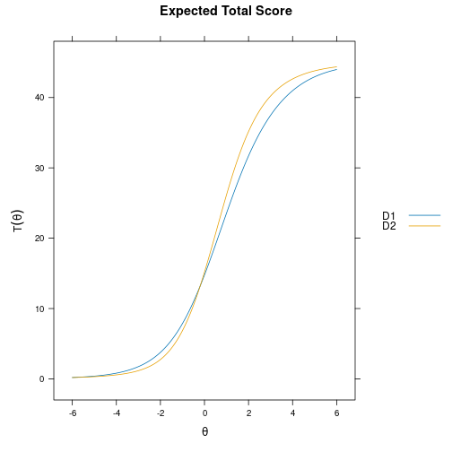

```r
############
# polytomous item example
set.seed(12345)
a <- matrix(abs(rnorm(15,1,.3)), ncol=1)
d <- matrix(rnorm(15,0,.7),ncol=1)
d <- cbind(d, d-1, d-2)
itemtype <- rep('graded', nrow(a))
N <- 1000
dataset1 <- simdata(a, d, N, itemtype)
dataset2 <- simdata(a, d, N, itemtype, mu = .1, sigma = matrix(1.5))
dat <- rbind(dataset1, dataset2)
group <- c(rep('D1', N), rep('D2', N))
model <- 'F1 = 1-15'

mod_configural <- multipleGroup(dat, model, group = group)
plot(mod_configural)
```

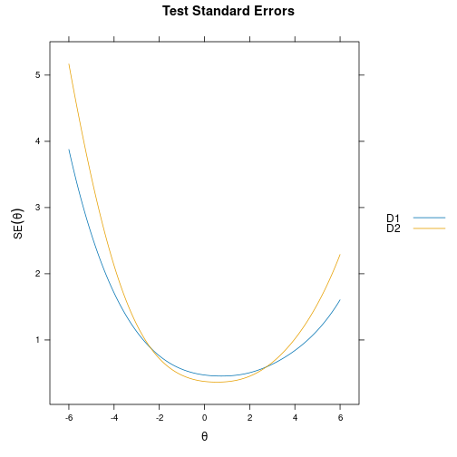

```r
plot(mod_configural, type = 'SE')
```

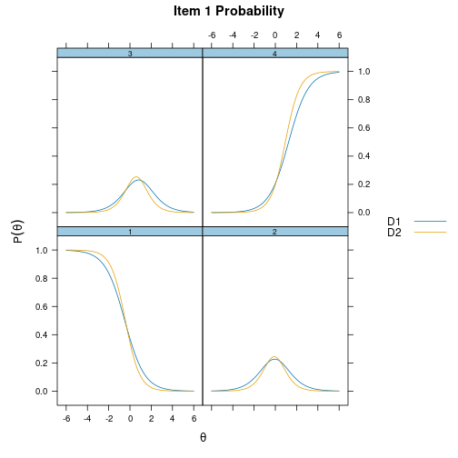

```r
itemplot(mod_configural, 1)
```

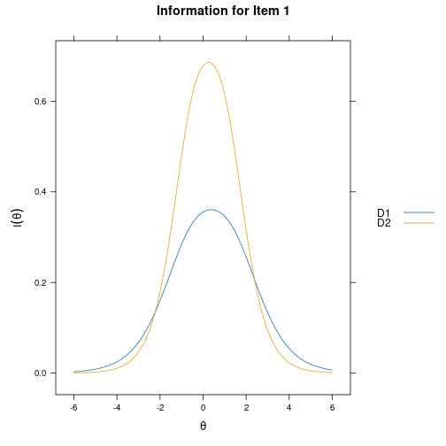

```r
itemplot(mod_configural, 1, type = 'info')
```

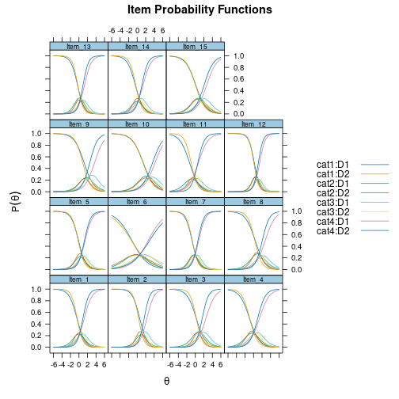

```r
plot(mod_configural, type = 'trace') # messy, score function typically better
```

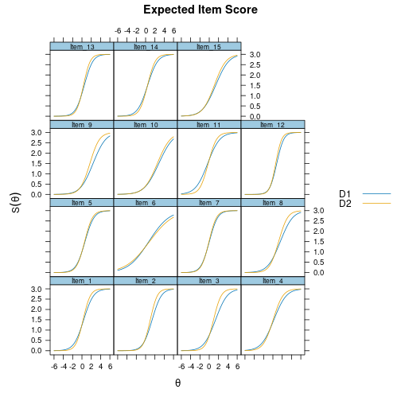

```r
plot(mod_configural, type = 'itemscore')
```

```r
fs <- fscores(mod_configural, full.scores = FALSE)
```

```
##
## Method:  EAP
##
## Empirical Reliability:
##
##     F1
## 0.7942
##
## Method:  EAP
##
## Empirical Reliability:
##
##     F1
## 0.7249
```

```r
head(fs[["D1"]])
```

```
##      Item_1 Item_2 Item_3 Item_4 Item_5 Item_6 Item_7 Item_8 Item_9 Item_10
## [1,]      0      0      0      0      0      0      0      0      0       0
## [2,]      0      0      0      0      0      0      0      0      0       0
## [3,]      0      0      0      0      0      0      0      0      0       0
## [4,]      0      0      0      0      0      0      0      0      0       0
## [5,]      0      0      0      0      0      0      0      0      0       0
## [6,]      0      0      0      0      0      0      0      0      0       0
##      Item_11 Item_12 Item_13 Item_14 Item_15        F1     SE_F1
## [1,]       0       0       0       0       0 -2.137056 0.6262714
## [2,]       0       0       0       1       0 -1.785692 0.5741235
## [3,]       0       0       0       2       0 -1.726621 0.5800312
## [4,]       0       0       0       3       0 -1.688716 0.5856268
## [5,]       0       0       0       3       1 -1.439230 0.5535499
## [6,]       0       2       0       0       0 -1.582715 0.5660598
```

```r
fscores(mod_configural, method = 'EAPsum', full.scores = FALSE)
```

```
##       df     X2  p.X2 SEM.alpha rxx.alpha rxx_F1
## stats 39 42.374 0.328     3.869     0.784  0.776
##
##       df     X2  p.X2 SEM.alpha rxx.alpha rxx_F1
## stats 42 29.475 0.928     3.825     0.842  0.832
```

```
## $D1
##    Sum.Scores     F1 SE_F1 observed expected std.res
## 0           0 -2.137 0.626        6    5.731   0.112
## 1           1 -1.842 0.589        6   10.082   1.286
## 2           2 -1.645 0.575       19   15.026   1.025
## 3           3 -1.491 0.568       22   21.117   0.192
## 4           4 -1.323 0.548       31   26.167   0.945
## 5           5 -1.173 0.534       21   30.811   1.768
## 6           6 -1.033 0.523       30   34.974   0.841
## 7           7 -0.898 0.510       37   38.286   0.208
## 8           8 -0.770 0.500       47   40.921   0.950
## 9           9 -0.648 0.490       40   42.896   0.442
## 10         10 -0.531 0.481       54   44.208   1.473
## 11         11 -0.417 0.473       52   44.945   1.052
## 12         12 -0.307 0.466       50   45.161   0.720
```

[output cut: 82 more lines]

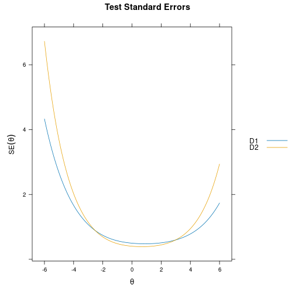

```r
# constrain slopes within each group to be equal (but not across groups)
model2 <- 'F1 = 1-15
           CONSTRAIN = (1-15, a1)'
mod_configural2 <- multipleGroup(dat, model2, group = group)
plot(mod_configural2, type = 'SE')
```

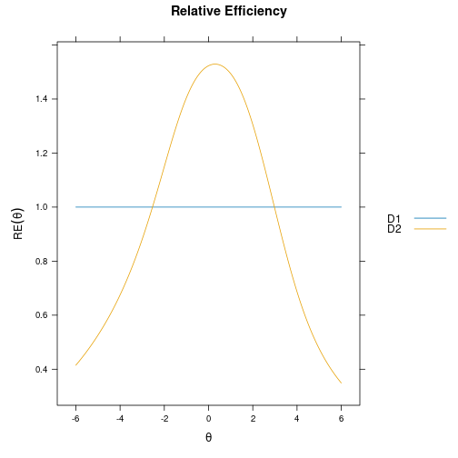

```r
plot(mod_configural2, type = 'RE')
```

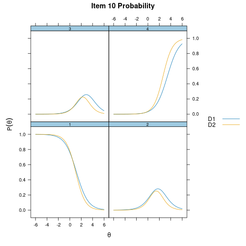

```r
itemplot(mod_configural2, 10)
```

```r
############
## empirical histogram example (normal and bimodal groups)
set.seed(1234)
a <- matrix(rlnorm(50, .2, .2))
d <- matrix(rnorm(50))
ThetaNormal <- matrix(rnorm(2000))
ThetaBimodal <- scale(matrix(c(rnorm(1000, -2), rnorm(1000,2)))) #bimodal
Theta <- rbind(ThetaNormal, ThetaBimodal)
dat <- simdata(a, d, 4000, itemtype = '2PL', Theta=Theta)
group <- rep(c('G1', 'G2'), each=2000)

EH <- multipleGroup(dat, 1, group=group, dentype="empiricalhist", invariance = colnames(dat))
coef(EH, simplify=TRUE)
```

```
## $G1
## $items
##            a1      d g u
## Item_1  0.759 -1.830 0 1
## Item_2  1.062 -0.555 0 1
## Item_3  1.235 -1.117 0 1
## Item_4  0.611 -0.953 0 1
## Item_5  1.088 -0.132 0 1
## Item_6  1.054  0.502 0 1
## Item_7  0.849  1.581 0 1
## Item_8  0.870 -0.779 0 1
## Item_9  0.902  1.658 0 1
## Item_10 0.812 -1.188 0 1
## Item_11 0.903  0.661 0 1
## Item_12 0.841  2.646 0 1
## Item_13 0.843 -0.064 0 1
## Item_14 1.009 -0.600 0 1
## Item_15 1.167  0.013 0 1
## Item_16 1.008  1.886 0 1
## Item_17 0.885 -1.124 0 1
## Item_18 0.790  1.420 0 1
## Item_19 0.799  1.316 0 1
## Item_20 1.565  0.294 0 1
## Item_21 1.002  0.001 0 1
## Item_22 0.929 -0.497 0 1
## Item_23 0.903 -0.383 0 1
## Item_24 1.120  0.702 0 1
## Item_25 0.850  2.002 0 1
## Item_26 0.706 -0.208 0 1
## Item_27 1.048 -1.279 0 1
## Item_28 0.826 -0.770 0 1
## Item_29 1.062  0.221 0 1
## Item_30 0.737 -0.333 0 1
## Item_31 1.208 -0.178 0 1
## Item_32 0.917 -0.202 0 1
## Item_33 0.859 -1.360 0 1
## Item_34 0.913 -0.252 0 1
## Item_35 0.767  0.886 0 1
## Item_36 0.783  0.763 0 1
## Item_37 0.630  0.550 0 1
```

[output cut: 69 more lines]

```
## Item_44 1.022  1.038 0 1
## Item_45 0.812 -0.470 0 1
## Item_46 0.807  0.336 0 1
## Item_47 0.815 -1.121 0 1
## Item_48 0.739  0.892 0 1
## Item_49 0.904  1.036 0 1
## Item_50 0.895  2.124 0 1
##
## $means
## F1
##  0
##
## $cov
##    F1
## F1  1
```

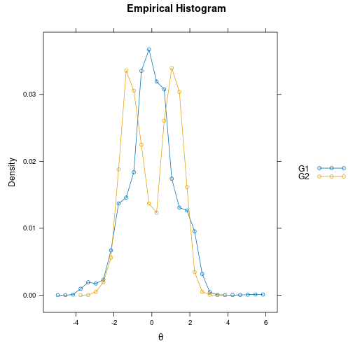

```r
plot(EH, type = 'empiricalhist', npts = 60)
```

```r
# DIF test for item 1
EH1 <- multipleGroup(dat, 1, group=group, dentype="empiricalhist", invariance = colnames(dat)[-1])
anova(EH, EH1)
```

```
##          AIC    SABIC       HQ      BIC    logLik    X2 df     p
## EH  216599.8 217659.4 217358.4 218739.8 -107959.9
## EH1 216602.9 217668.7 217365.9 218755.4 -107959.4 0.916  2 0.632
```

```r
#--------------------------------
# Mixture model (no prior group variable specified)

set.seed(12345)
nitems <- 20
a1 <- matrix(.75, ncol=1, nrow=nitems)
a2 <- matrix(1.25, ncol=1, nrow=nitems)
d1 <- matrix(rnorm(nitems,0,1),ncol=1)
d2 <- matrix(rnorm(nitems,0,1),ncol=1)
itemtype <- rep('2PL', nrow(a1))
N1 <- 500
N2 <- N1*2 # second class twice as large

dataset1 <- simdata(a1, d1, N1, itemtype)
dataset2 <- simdata(a2, d2, N2, itemtype)
dat <- rbind(dataset1, dataset2)
# group <- c(rep('D1', N1), rep('D2', N2))

# Mixture Rasch model (Rost, 1990)
models <- 'F1 = 1-20
           CONSTRAIN = (1-20, a1)'
mod_mix <- multipleGroup(dat, models, dentype = 'mixture-2', GenRandomPars = TRUE)
coef(mod_mix, simplify=TRUE)
```

```
## $MIXTURE_1
## $items
##            a1      d g u
## Item_1  1.302  0.772 0 1
## Item_2  1.302  1.476 0 1
## Item_3  1.302 -0.553 0 1
## Item_4  1.302 -1.588 0 1
## Item_5  1.302 -1.545 0 1
## Item_6  1.302  2.084 0 1
## Item_7  1.302 -0.510 0 1
## Item_8  1.302  0.606 0 1
## Item_9  1.302  0.550 0 1
## Item_10 1.302 -0.167 0 1
## Item_11 1.302  0.961 0 1
## Item_12 1.302  2.156 0 1
## Item_13 1.302  2.082 0 1
## Item_14 1.302  1.733 0 1
## Item_15 1.302  0.138 0 1
## Item_16 1.302  0.434 0 1
## Item_17 1.302 -0.368 0 1
## Item_18 1.302 -1.633 0 1
## Item_19 1.302  1.799 0 1
## Item_20 1.302 -0.024 0 1
##
## $means
## F1
##  0
##
## $cov
##    F1
## F1  1
##
## $class_proportion
##     pi
##  0.655
##
##
## $MIXTURE_2
## $items
##            a1      d g u
```

[output cut: 17 more lines]

```
## Item_18 0.681 -0.345 0 1
## Item_19 0.681  1.230 0 1
## Item_20 0.681  0.271 0 1
##
## $means
## F1
##  0
##
## $cov
##    F1
## F1  1
##
## $class_proportion
##     pi
##  0.345
```

```r
summary(mod_mix)
```

```
##
## ----------
## GROUP: MIXTURE_1
##            F1    h2
## Item_1  0.608 0.369
## Item_2  0.608 0.369
## Item_3  0.608 0.369
## Item_4  0.608 0.369
## Item_5  0.608 0.369
## Item_6  0.608 0.369
## Item_7  0.608 0.369
## Item_8  0.608 0.369
## Item_9  0.608 0.369
## Item_10 0.608 0.369
## Item_11 0.608 0.369
## Item_12 0.608 0.369
## Item_13 0.608 0.369
## Item_14 0.608 0.369
## Item_15 0.608 0.369
## Item_16 0.608 0.369
## Item_17 0.608 0.369
## Item_18 0.608 0.369
## Item_19 0.608 0.369
## Item_20 0.608 0.369
##
## SS loadings:  7.386
## Proportion Var:  0.369
##
## Factor correlations:
##
##    F1
## F1  1
##
## Class proportion:  0.655
##
## ----------
## GROUP: MIXTURE_2
##            F1    h2
## Item_1  0.371 0.138
## Item_2  0.371 0.138
```

[output cut: 13 more lines]

```
## Item_16 0.371 0.138
## Item_17 0.371 0.138
## Item_18 0.371 0.138
## Item_19 0.371 0.138
## Item_20 0.371 0.138
##
## SS loadings:  2.758
## Proportion Var:  0.138
##
## Factor correlations:
##
##    F1
## F1  1
##
## Class proportion:  0.345
```

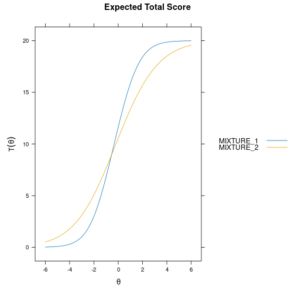

```r
plot(mod_mix)
```

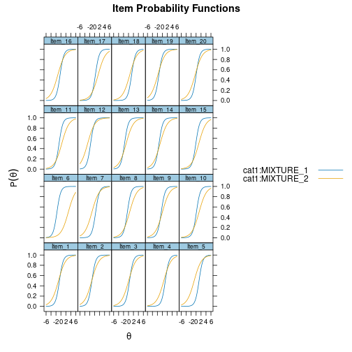

```r
plot(mod_mix, type = 'trace')
```

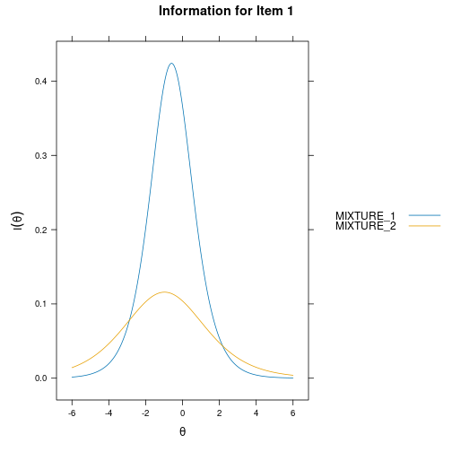

```r
itemplot(mod_mix, 1, type = 'info')
```

```r
head(fscores(mod_mix)) # theta estimates
```

```
##         Class_1
## [1,] -0.3609178
## [2,] -1.6950807
## [3,] -0.8217168
## [4,]  0.8090483
## [5,]  0.7936363
## [6,]  0.2286020
```

```r
head(fscores(mod_mix, method = 'classify')) # classification probability
```

```
##         CLASS_1   CLASS_2
## [1,] 0.04826707 0.9517329
## [2,] 0.74223456 0.2577654
## [3,] 0.02496631 0.9750337
## [4,] 0.02929597 0.9707040
## [5,] 0.07220958 0.9277904
## [6,] 0.42428417 0.5757158
```

```r
itemfit(mod_mix)
```

```
##       item   S_X2 df.S_X2 RMSEA.S_X2 p.S_X2
## 1   Item_1 30.498      12      0.032  0.002
## 2   Item_2 36.271      12      0.037  0.000
## 3   Item_3 15.756      12      0.014  0.203
## 4   Item_4  9.334      11      0.000  0.591
## 5   Item_5 21.638      12      0.023  0.042
## 6   Item_6 26.071      13      0.026  0.017
## 7   Item_7  8.624      12      0.000  0.735
## 8   Item_8 16.652      12      0.016  0.163
## 9   Item_9 22.772      12      0.024  0.030
## 10 Item_10 14.622      12      0.012  0.263
## 11 Item_11  7.357      12      0.000  0.833
## 12 Item_12 14.964      12      0.013  0.243
## 13 Item_13 10.222      12      0.000  0.597
## 14 Item_14 17.414      13      0.015  0.181
## 15 Item_15  9.436      12      0.000  0.665
## 16 Item_16 11.408      12      0.000  0.494
## 17 Item_17 16.483      12      0.016  0.170
## 18 Item_18 11.717      11      0.007  0.385
## 19 Item_19 11.425      12      0.000  0.493
## 20 Item_20 15.291      12      0.014  0.226
```

```r
# Mixture 2PL model
mod_mix2 <- multipleGroup(dat, 1, dentype = 'mixture-2', GenRandomPars = TRUE)
anova(mod_mix, mod_mix2)
```

```
##               AIC    SABIC       HQ      BIC    logLik     X2 df    p
## mod_mix  34628.19 34720.06 34713.30 34856.65 -17271.09
## mod_mix2 34655.23 34828.29 34815.56 35085.60 -17246.62 48.957 38 0.11
```

```r
coef(mod_mix2, simplify=TRUE)
```

```
## $MIXTURE_1
## $items
##            a1      d g u
## Item_1  0.517  0.672 0 1
## Item_2  0.516  0.826 0 1
## Item_3  0.533 -0.012 0 1
## Item_4  0.387 -0.363 0 1
## Item_5  0.452  0.551 0 1
## Item_6  0.727 -1.905 0 1
## Item_7  1.032  0.879 0 1
## Item_8  0.744 -0.275 0 1
## Item_9  0.900  0.037 0 1
## Item_10 0.709 -0.777 0 1
## Item_11 0.538 -0.190 0 1
## Item_12 0.915  2.079 0 1
## Item_13 0.729  0.690 0 1
## Item_14 1.183  0.722 0 1
## Item_15 0.812 -0.717 0 1
## Item_16 0.582  0.843 0 1
## Item_17 0.791 -0.953 0 1
## Item_18 0.657 -0.290 0 1
## Item_19 0.498  1.222 0 1
## Item_20 0.468  0.304 0 1
##
## $means
## F1
##  0
##
## $cov
##    F1
## F1  1
##
## $class_proportion
##     pi
##  0.349
##
##
## $MIXTURE_2
## $items
##            a1      d g u
```

[output cut: 17 more lines]

```
## Item_18 1.500 -1.798 0 1
## Item_19 1.624  1.955 0 1
## Item_20 1.353 -0.060 0 1
##
## $means
## F1
##  0
##
## $cov
##    F1
## F1  1
##
## $class_proportion
##     pi
##  0.651
```

```r
itemfit(mod_mix2)
```

```
##       item   S_X2 df.S_X2 RMSEA.S_X2 p.S_X2
## 1   Item_1 21.271      12      0.023  0.047
## 2   Item_2 44.619      13      0.040  0.000
## 3   Item_3 14.259      12      0.011  0.284
## 4   Item_4  6.550      11      0.000  0.834
## 5   Item_5 20.639      12      0.022  0.056
## 6   Item_6 27.956      13      0.028  0.009
## 7   Item_7  8.628      12      0.000  0.734
## 8   Item_8 16.261      12      0.015  0.180
## 9   Item_9 21.304      12      0.023  0.046
## 10 Item_10 11.460      12      0.000  0.490
## 11 Item_11  7.091      12      0.000  0.852
## 12 Item_12 13.838      12      0.010  0.311
## 13 Item_13 10.444      12      0.000  0.577
## 14 Item_14 15.704      13      0.012  0.265
## 15 Item_15  9.439      12      0.000  0.665
## 16 Item_16 10.128      12      0.000  0.605
## 17 Item_17 17.474      12      0.017  0.133
## 18 Item_18 11.833      11      0.007  0.376
## 19 Item_19  8.071      11      0.000  0.707
## 20 Item_20 14.542      12      0.012  0.267
```

```r
# Compare to single group
mod <- mirt(dat)
anova(mod, mod_mix2)
```

```
##               AIC    SABIC       HQ      BIC    logLik      X2 df p
## mod      35276.70 35362.16 35355.88 35489.23 -17598.35
## mod_mix2 34655.23 34828.29 34815.56 35085.60 -17246.62 703.474 41 0
```

```r
########################################
# Zero-inflated 2PL IRT model (Wall, Park, and Moustaki, 2015)

n <- 1000
nitems <- 20

a <- rep(2, nitems)
d <- rep(c(-2,-1,0,1,2), each=nitems/5)
zi_p <- 0.2 # Proportion of people in zero class

theta <- rnorm(n, 0, 1)
zeros <- matrix(0, n*zi_p, nitems)
nonzeros <- simdata(a, d, n*(1-zi_p), itemtype = '2PL',
                   Theta = as.matrix(theta[1:(n*(1-zi_p))]))
data <- rbind(nonzeros, zeros)

# define class with extreme theta but fixed item parameters
zi2PL <- "F = 1-20
          START [MIXTURE_1] = (GROUP, MEAN_1, -100), (GROUP, COV_11, .00001),
                              (1-20, a1, 1.0), (1-20, d, 0)
          FIXED [MIXTURE_1] = (GROUP, MEAN_1), (GROUP, COV_11),
                              (1-20, a1), (1-20, d)"

# define custom Theta integration grid that contains extreme theta + normal grid
technical <- list(customTheta = matrix(c(-100, seq(-6,6,length.out=61))))

# fit ZIM-IRT
zi2PL.fit <- multipleGroup(data, zi2PL, dentype = 'mixture-2', technical=technical)
coef(zi2PL.fit, simplify=TRUE)
```

```
## $MIXTURE_1
## $items
##         a1 d g u
## Item_1   1 0 0 1
## Item_2   1 0 0 1
## Item_3   1 0 0 1
## Item_4   1 0 0 1
## Item_5   1 0 0 1
## Item_6   1 0 0 1
## Item_7   1 0 0 1
## Item_8   1 0 0 1
## Item_9   1 0 0 1
## Item_10  1 0 0 1
## Item_11  1 0 0 1
## Item_12  1 0 0 1
## Item_13  1 0 0 1
## Item_14  1 0 0 1
## Item_15  1 0 0 1
## Item_16  1 0 0 1
## Item_17  1 0 0 1
## Item_18  1 0 0 1
## Item_19  1 0 0 1
## Item_20  1 0 0 1
##
## $means
##    F
## -100
##
## $cov
##   F
## F 0
##
## $class_proportion
##     pi
##  0.209
##
##
## $MIXTURE_2
## $items
##            a1      d g u
```

[output cut: 17 more lines]

```
## Item_18 1.917  2.153 0 1
## Item_19 1.464  1.735 0 1
## Item_20 1.739  1.920 0 1
##
## $means
## F
## 0
##
## $cov
##   F
## F 1
##
## $class_proportion
##     pi
##  0.791
```

```r
# classification estimates
pi_hat <- fscores(zi2PL.fit, method = 'classify')
head(pi_hat)
```

```
##            CLASS_1 CLASS_2
## [1,] 8.544142e-180       1
## [2,]  2.267724e-14       1
## [3,] 2.122840e-178       1
## [4,] 4.509158e-210       1
## [5,]  1.130538e-13       1
## [6,] 9.974115e-149       1
```

```r
tail(pi_hat)
```

```
##           CLASS_1    CLASS_2
##  [995,] 0.9243758 0.07562418
##  [996,] 0.9243758 0.07562418
##  [997,] 0.9243758 0.07562418
##  [998,] 0.9243758 0.07562418
##  [999,] 0.9243758 0.07562418
## [1000,] 0.9243758 0.07562418
```

```r
# EAP estimates (not useful for zip class)
fs <- fscores(zi2PL.fit)
head(fs)
```

```
##           Class_1
## [1,]  0.262140462
## [2,] -1.762463343
## [3,]  0.285984614
## [4,]  0.562650718
## [5,] -1.669323391
## [6,]  0.005541674
```

```r
tail(fs)
```

```
##           Class_1
##  [995,] -92.59647
##  [996,] -92.59647
##  [997,] -92.59647
##  [998,] -92.59647
##  [999,] -92.59647
## [1000,] -92.59647
```

```r
########################################
# Zero-inflated graded response model (Magnus and Garnier-Villarreal, 2022)

n <- 1000
nitems <- 20

a <- matrix(rlnorm(20,.2,.3))

# for the graded model, ensure that there is enough space between the intercepts,
# otherwise closer categories will not be selected often (minimum distance of 0.3 here)
diffs <- t(apply(matrix(runif(20*4, .3, 1), 20), 1, cumsum))
diffs <- -(diffs - rowMeans(diffs))
d <- diffs + rnorm(20)

zi_p <- 0.2 # Proportion of people in zero/lowest category class

theta <- rnorm(n, 0, 1)
zeros <- matrix(0, n*zi_p, nitems)
nonzeros <- simdata(a, d, n*(1-zi_p), itemtype = 'graded',
                    Theta = as.matrix(theta[1:(n*(1-zi_p))]))
data <- rbind(nonzeros, zeros)

# intercepts will be labelled as d1 through d4
apply(data, 2, table)
```

```
##   Item_1 Item_2 Item_3 Item_4 Item_5 Item_6 Item_7 Item_8 Item_9 Item_10
## 0    474    276    431    384    763    354    420    379    342     610
## 1    128     61    107     26     69     99    140    137    116     114
## 2     62    105    112     54     45     58    120    136    165      98
## 3     89    135    159     87     37    135    118     70     68      34
## 4    247    423    191    449     86    354    202    278    309     144
##   Item_11 Item_12 Item_13 Item_14 Item_15 Item_16 Item_17 Item_18 Item_19
## 0     393     756     668     605     463     321     683     664     406
## 1     115     114      75     104      74      55      65      46      99
## 2      54      62      55     113     119     123      58      46      66
## 3     134      33      66      81      89     130      42      57      67
## 4     304      35     136      97     255     371     152     187     362
##   Item_20
## 0     588
## 1     103
## 2      85
## 3      50
## 4     174
```

```r
# ignoring zero inflation (bad idea)
modGRM <- mirt(data)
coef(modGRM, simplify=TRUE)
```

```
## $items
##            a1     d1     d2     d3     d4
## Item_1  2.540 -0.222 -1.106 -1.527 -2.166
## Item_2  2.284  1.418  0.791 -0.010 -0.848
## Item_3  1.771  0.167 -0.479 -1.108 -2.132
## Item_4  3.367  0.392  0.141 -0.330 -1.021
## Item_5  3.450 -2.805 -3.524 -4.104 -4.690
## Item_6  2.003  0.715  0.013 -0.347 -1.145
## Item_7  2.375  0.182 -0.781 -1.545 -2.404
## Item_8  2.286  0.516 -0.465 -1.336 -1.795
## Item_9  2.768  0.837 -0.152 -1.318 -1.801
## Item_10 2.910 -1.290 -2.154 -3.033 -3.397
## Item_11 2.681  0.382 -0.484 -0.857 -1.792
## Item_12 1.734 -1.721 -2.648 -3.462 -4.224
## Item_13 2.042 -1.306 -1.802 -2.209 -2.804
## Item_14 1.914 -0.871 -1.516 -2.346 -3.184
## Item_15 4.247 -0.504 -1.187 -2.250 -3.114
## Item_16 2.628  1.020  0.501 -0.428 -1.305
## Item_17 2.522 -1.628 -2.114 -2.605 -3.007
## Item_18 2.547 -1.507 -1.835 -2.189 -2.675
## Item_19 1.906  0.340 -0.291 -0.677 -1.065
## Item_20 2.287 -0.906 -1.572 -2.181 -2.606
##
## $means
## F1
##  0
##
## $cov
##    F1
## F1  1
```

```r
# Define class with extreme theta but fixed item parameters
#   For GRM in zero-inflated class the intercept values are arbitrary
#   as the model forces the responses all into the first category (hence,
#   spacing arbitrarily set to 1)
ziGRM <- "F = 1-20
          START [MIXTURE_1] = (GROUP, MEAN_1, -100), (GROUP, COV_11, .00001),
                              (1-20, a1, 1.0),
                              (1-20, d1, 2), (1-20, d2, 1), (1-20, d3, 0), (1-20, d4, -1)
          FIXED [MIXTURE_1] = (GROUP, MEAN_1), (GROUP, COV_11),
                              (1-20, a1),
                              (1-20, d1), (1-20, d2), (1-20, d3), (1-20, d4)"

# define custom Theta integration grid that contains extreme theta + normal grid
technical <- list(customTheta = matrix(c(-100, seq(-6,6,length.out=61))))

# fit zero-inflated GRM
ziGRM.fit <- multipleGroup(data, ziGRM, dentype = 'mixture-2', technical=technical)
coef(ziGRM.fit, simplify=TRUE)
```

```
## $MIXTURE_1
## $items
##         a1 d1 d2 d3 d4
## Item_1   1  2  1  0 -1
## Item_2   1  2  1  0 -1
## Item_3   1  2  1  0 -1
## Item_4   1  2  1  0 -1
## Item_5   1  2  1  0 -1
## Item_6   1  2  1  0 -1
## Item_7   1  2  1  0 -1
## Item_8   1  2  1  0 -1
## Item_9   1  2  1  0 -1
## Item_10  1  2  1  0 -1
## Item_11  1  2  1  0 -1
## Item_12  1  2  1  0 -1
## Item_13  1  2  1  0 -1
## Item_14  1  2  1  0 -1
## Item_15  1  2  1  0 -1
## Item_16  1  2  1  0 -1
## Item_17  1  2  1  0 -1
## Item_18  1  2  1  0 -1
## Item_19  1  2  1  0 -1
## Item_20  1  2  1  0 -1
##
## $means
##    F
## -100
##
## $cov
##   F
## F 0
##
## $class_proportion
##   pi
##  0.2
##
##
## $MIXTURE_2
## $items
##            a1     d1     d2     d3     d4
```

[output cut: 17 more lines]

```
## Item_18 1.359 -0.428 -0.755 -1.108 -1.591
## Item_19 0.725  1.173  0.539  0.161 -0.216
## Item_20 1.179  0.077 -0.586 -1.190 -1.609
##
## $means
## F
## 0
##
## $cov
##   F
## F 1
##
## $class_proportion
##   pi
##  0.8
```

```r
# classification estimates
pi_hat <- fscores(ziGRM.fit, method = 'classify')
head(pi_hat)
```

```
##            CLASS_1 CLASS_2
## [1,] 7.494632e-176       1
## [2,] 9.061521e-303       1
## [3,] 8.797228e-303       1
## [4,] 8.991330e-293       1
## [5,] 2.992170e-231       1
## [6,]  1.967058e-82       1
```

```r
tail(pi_hat)
```

```
##           CLASS_1     CLASS_2
##  [995,] 0.9982456 0.001754397
##  [996,] 0.9982456 0.001754397
##  [997,] 0.9982456 0.001754397
##  [998,] 0.9982456 0.001754397
##  [999,] 0.9982456 0.001754397
## [1000,] 0.9982456 0.001754397
```

```r
# EAP estimates (not useful for zip class)
fs <- fscores(ziGRM.fit)
head(fs)
```

```
##         Class_1
## [1,] -0.5412083
## [2,]  0.8572725
## [3,]  1.5055425
## [4,]  1.1937281
## [5,]  0.2213622
## [6,] -1.4092124
```

```r
tail(fs)
```

```
##           Class_1
##  [995,] -99.82944
##  [996,] -99.82944
##  [997,] -99.82944
##  [998,] -99.82944
##  [999,] -99.82944
## [1000,] -99.82944
```

```r
## End(No test)
```

[Package *mirt* version 1.43 Index]